# Bayesian data analysis - traffic deaths in Finland

Aki Vehtari

First version 2017-09-28. Last modified 2018-10-12.

# Setup

**Load packages**

```r
library(ggplot2)
library(tidyr)
library(gridExtra)
library(rstanarm)
library(rstan)
library(bayesplot)
theme_set(theme_minimal())
library(loo)
rstan_options(auto_write = TRUE)
options(mc.cores = parallel::detectCores())
source("stan_utility.R")
```

# 1 Introduction

This notebook demonstrates time series analysis for traffic deaths per year in Finland. Currently when the the number of traffic deaths during previous year are reported, the press release claims that the the traffic safety in Finland has improved or worsened depending whether the number is smaller or larger than the year before. Time series analysis can be used to separate random fluctuation from the slowly changing traffic safety.

# 2 Data

Read the data (there would data for earlier years, too, but this is sufficient for the demonstration)

```r
# file preview shows a header row
deaths <- read.csv("trafficdeaths.csv", header = TRUE)
head(deaths)
```

```
  year deaths
1 1993    434
2 1994    423
3 1995    411
4 1996    355
5 1997    391
6 1998    367
```

First plot just the data.

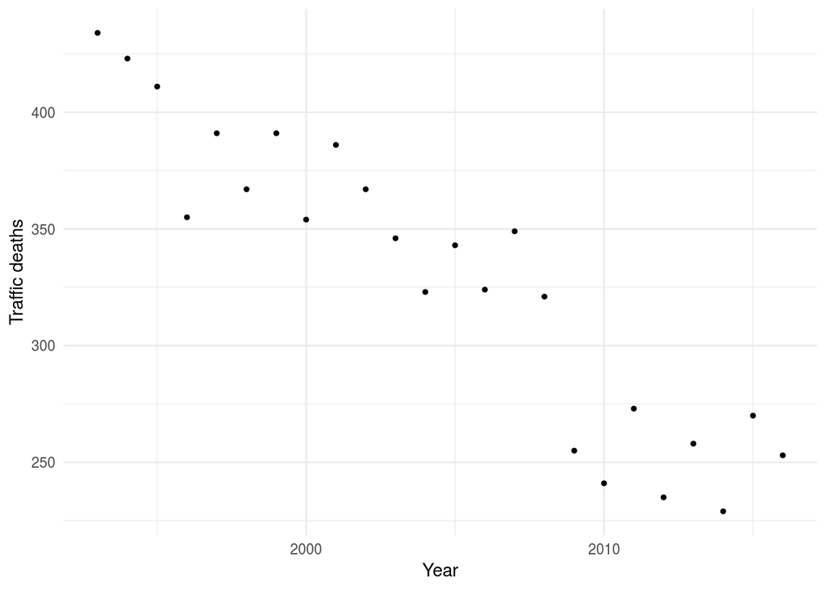

```r
ggplot() +
  geom_point(aes(year, deaths), data = deaths, size = 1) +
  labs(y = 'Traffic deaths', x= "Year") +
  guides(linetype = F)
```

# 3 Poisson regression model

The number of deaths is count data, so we use Poisson observation model. We first fit log-linear model for the Poisson intensity, which corresponds to assuming constant proportional change in the rate.

```r
fit_lin <- stan_glm(deaths ~ year, data = deaths, family="poisson",
                refresh=1000, iter=1000, chains=4, seed=583829)
```

```r
summary(fit_lin, probs=c(0.1, 0.5, 0.9))
```

```
Model Info:

 function:     stan_glm
 family:       poisson [log]
 formula:      deaths ~ year
 algorithm:    sampling
 priors:       see help('prior_summary')
 sample:       2000 (posterior sample size)
 observations: 24
 predictors:   2

Estimates:
                mean   sd     10%    50%    90%
(Intercept)     56.8    3.4   52.4   56.9   61.2
year             0.0    0.0    0.0    0.0    0.0
mean_PPD       329.3    5.2  322.6  329.2  335.9
log-posterior -117.7    1.0 -119.1 -117.4 -116.8

Diagnostics:
              mcse Rhat n_eff
(Intercept)   0.1  1.0  1153
year          0.0  1.0  1152
mean_PPD      0.1  1.0  1426
log-posterior 0.0  1.0   819

For each parameter, mcse is Monte Carlo standard error, n_eff is a crude measure of effective sample size, and Rhat is the potential scale reduction factor on split chains (at convergence Rhat=1).
```

n_eff’s and Rhat’s are ok (see, e.g., [RStan workflow](http://mc-stan.org/users/documentation/case-studies/rstan_workflow.html)). Let’s look at the posterior predictive distribution (median and 5% and 95% intervals).

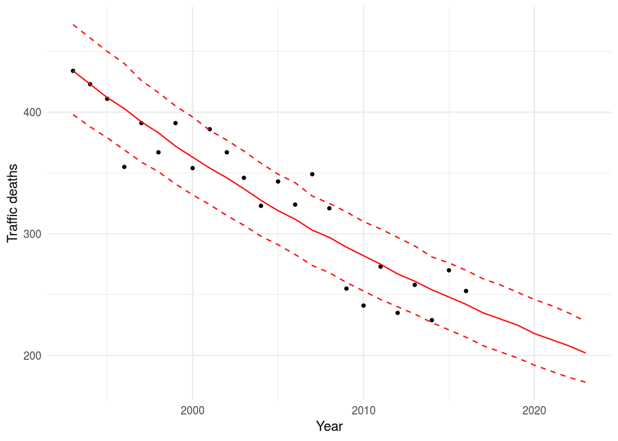

```r
x_predict <- seq(1993,2023)
N_predict <- length(x_predict)
y_predict <- posterior_predict(fit_lin, newdata=data.frame(year=x_predict))
mu <- apply(t(y_predict), 1, quantile, c(0.05, 0.5, 0.95)) %>%
  t() %>% data.frame(x = x_predict, .) %>% gather(pct, y, -x)
pfit <- ggplot() +
  geom_point(aes(year, deaths), data = deaths, size = 1) +
  geom_line(aes(x, y, linetype = pct), data = mu, color = 'red') +
  scale_linetype_manual(values = c(2,1,2)) +
  labs(x = 'Year', y = 'Traffic deaths') +
  guides(linetype = F)
(pfit)
```

Next we fit a non-linear spline model with `stan_gamm4`

```r
fit_gam <- stan_gamm4(deaths ~ year + s(year), data=deaths,
                      family="poisson", adapt_delta=0.999,
                      refresh=1000, iter=2000, chain=4, seed=583829)
summary(fit_gam, probs=c(0.1, 0.5, 0.9))
```

```
Model Info:

 function:     stan_gamm4
 family:       poisson [log]
 formula:      deaths ~ year + s(year)
 algorithm:    sampling
 priors:       see help('prior_summary')
 sample:       4000 (posterior sample size)
 observations: 24

Estimates:
                      mean   sd     10%    50%    90%
(Intercept)           36.8   78.4  -40.9   39.3  113.4
year                   0.0    0.0   -0.1    0.0    0.0
s(year).1              0.1    0.6   -0.5    0.1    0.8
s(year).2             -0.5    0.6   -1.3   -0.4    0.1
s(year).3             -0.2    0.5   -0.8   -0.1    0.3
s(year).4              0.1    0.4   -0.3    0.1    0.5
s(year).5             -0.2    0.3   -0.6   -0.1    0.2
s(year).6              0.5    0.2    0.2    0.5    0.8
s(year).7              0.2    0.2    0.0    0.2    0.4
s(year).8             -0.4    0.3   -0.8   -0.3    0.0
s(year).9              0.0    1.4   -1.3    0.0    1.2
smooth_sd[s(year)1]    0.5    0.3    0.2    0.5    0.9
smooth_sd[s(year)2]    1.0    1.0    0.1    0.7    2.3
mean_PPD             329.1    5.1  322.6  329.1  335.5
log-posterior       -127.2    3.5 -131.8 -126.9 -122.9

Diagnostics:
                    mcse Rhat n_eff
(Intercept)         2.7  1.0   831
year                0.0  1.0   831
s(year).1           0.0  1.0  2545
s(year).2           0.0  1.0  1703
s(year).3           0.0  1.0  2852
s(year).4           0.0  1.0  2855
s(year).5           0.0  1.0  3408
s(year).6           0.0  1.0  1068
s(year).7           0.0  1.0  1880
s(year).8           0.0  1.0  1674
s(year).9           0.0  1.0   849
smooth_sd[s(year)1] 0.0  1.0   872
smooth_sd[s(year)2] 0.0  1.0  1804
mean_PPD            0.1  1.0  4000
log-posterior       0.1  1.0   629

For each parameter, mcse is Monte Carlo standard error, n_eff is a crude measure of effective sample size, and Rhat is the potential scale reduction factor on split chains (at convergence Rhat=1).
```

n_eff is clearly smaller than for the linear model, but Rhat’s are ok.

Let’s look at the posterior predictive distribution.

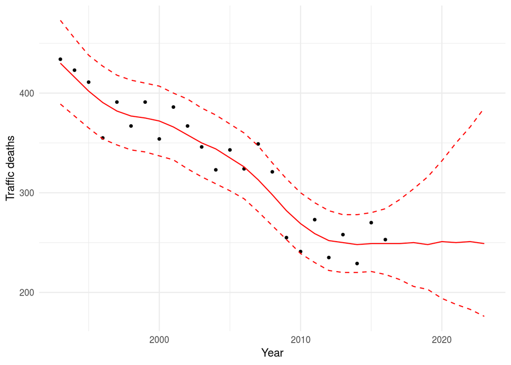

```r
x_predict=seq(1993,2023)
N_predict=length(x_predict)
y_predict <- posterior_predict(fit_gam, newdata=data.frame(year=x_predict))
mu <- apply(t(y_predict), 1, quantile, c(0.05, 0.5, 0.95)) %>%
  t() %>% data.frame(x = x_predict, .) %>% gather(pct, y, -x)
pfit <- ggplot() +
  geom_point(aes(year, deaths), data = deaths, size = 1) +
  geom_line(aes(x, y, linetype = pct), data = mu, color = 'red') +
  scale_linetype_manual(values = c(2,1,2)) +
  labs(x = 'Year', y = 'Traffic deaths') +
  guides(linetype = F)
(pfit)
```

The predictive median is clearly nonlinear. The predictive mean for future years stays at the same level as the most recent observations, but uncertainty increases quickly.

Finally we fit Gaussian process centered on linear model. This is not yet available in rstanarm, and has been written directly in Stan language:

```r
writeLines(readLines("poisson_gp.stan"))
```

```
functions {
  vector gp_pred_rng(vector x2,
                     vector f1, vector x1,
                     real alpha, real lscale, real jitter2) {
    // rng for predictive distribution of latent values at test locations
    int N1 = rows(x1);
    int N2 = rows(x2);
    vector[N2] f2;
    {
      matrix[N1, N1] K = cov_exp_quad(to_array_1d(x1), alpha, lscale)
                         + diag_matrix(rep_vector(jitter2, N1));
      matrix[N1, N1] L_K = cholesky_decompose(K);

      vector[N1] L_K_div_f1 = mdivide_left_tri_low(L_K, f1);
      vector[N1] K_div_f1 = mdivide_right_tri_low(L_K_div_f1', L_K)';
      matrix[N1, N2] k_x1_x2 = cov_exp_quad(to_array_1d(x1), to_array_1d(x2), alpha, lscale);
      vector[N2] f2_mu = (k_x1_x2' * K_div_f1);
      matrix[N1, N2] v_pred = mdivide_left_tri_low(L_K, k_x1_x2);
      matrix[N2, N2] cov_f2 = cov_exp_quad(to_array_1d(x2), alpha, lscale) - v_pred' * v_pred + diag_matrix(rep_vector(jitter2, N2));
      f2 = multi_normal_rng(f2_mu, cov_f2);
    }
    return f2;
  }
}

data {
  int<lower=1> N;
  vector[N] x;
  int<lower=0> y[N];
  real<lower=0> Ey;       // expected count

  int<lower=1> N_predict;
  vector[N_predict] x_predict;

  real<lower=0> alpha0;   // lscale prior parameter
  real<lower=0> beta0;    // lscale prior parameter
}

transformed data {
  real jitter2 = 1e-6;    // jitter to stabilize covariance matrices
```

[output cut: 37 more lines]

```
    vector[N] f;
    vector[N_predict] f_predict;
    matrix[N, N] cov = cov_exp_quad(to_array_1d(xc), alpha, lscale)
                       + diag_matrix(rep_vector(jitter2, N));
    matrix[N, N] L_cov = cholesky_decompose(cov);
    f = L_cov*z;
    f_predict = gp_pred_rng(xcp, f, xc, alpha, lscale, jitter2);
    for (n in 1:N_predict)
      mu_predict[n] = exp(log(Ey) + a + xcp[n]*b + f_predict[n]);
    for (n in 1:N_predict)
      y_predict[n] = poisson_log_rng(log(Ey) + a + xcp[n]*b + f_predict[n]);
    for (n in 1:N)
      log_lik[n] = poisson_log_lpmf(y[n] | log(Ey) + a + xc[n]*b + f[n]);
  }
}
```

```r
N<-nrow(deaths)
Ey<-mean(deaths$deaths)
d_data <- list(N=N, x=deaths$year, y=deaths$deaths, Ey=Ey, N_predict=N_predict,
                     x_predict=x_predict, alpha0=2, beta0=4)
fit_gp <- stan(file='poisson_gp.stan', data=d_data, refresh=1000, iter=4000,
                     chains=4, seed=583829, init=0, control=list(adapt_delta=0.999))
```

Check inference.

```r
monitor(fit_gp, probs=c(0.1, 0.5, 0.9))
```

```
Inference for the input samples (4 chains: each with iter=2000; warmup=0):

                  mean se_mean   sd     10%     50%     90% n_eff Rhat
lscale             2.8     0.1  2.9     1.1     2.2     5.0  1261    1
alpha              0.1     0.0  0.1     0.0     0.1     0.1  1611    1
a                  0.0     0.0  0.0    -0.1     0.0     0.0  4254    1
b                  0.0     0.0  0.0     0.0     0.0     0.0  3361    1
z[1]               0.0     0.0  0.8    -1.1     0.0     1.0  5929    1
z[2]              -0.4     0.0  0.8    -1.3    -0.4     0.6  8000    1
z[3]              -0.3     0.0  0.9    -1.5    -0.4     0.8  4187    1
z[4]              -0.1     0.0  0.9    -1.3    -0.1     1.1  8000    1
z[5]               0.2     0.0  0.9    -0.9     0.2     1.3  8000    1
z[6]               0.2     0.0  0.9    -1.0     0.2     1.3  8000    1
z[7]               0.2     0.0  0.9    -0.9     0.2     1.4  8000    1
z[8]               0.2     0.0  0.9    -0.9     0.2     1.4  8000    1
z[9]               0.3     0.0  0.9    -1.0     0.3     1.4  8000    1
z[10]              0.1     0.0  0.9    -1.1     0.1     1.2  8000    1
z[11]              0.1     0.0  0.9    -1.0     0.1     1.3  8000    1
z[12]              0.3     0.0  1.0    -1.0     0.3     1.5  8000    1
z[13]              0.3     0.0  1.0    -1.1     0.3     1.6  8000    1
z[14]              0.0     0.0  1.1    -1.4     0.1     1.4  3452    1
z[15]             -0.3     0.0  1.1    -1.6    -0.3     1.2  4125    1
z[16]             -0.7     0.0  1.0    -1.9    -0.7     0.6  8000    1
z[17]             -0.6     0.0  1.0    -1.8    -0.6     0.7  3672    1
z[18]             -0.2     0.0  1.0    -1.4    -0.2     1.1  8000    1
z[19]             -0.1     0.0  1.0    -1.3    -0.1     1.1  8000    1
z[20]             -0.1     0.0  1.0    -1.4    -0.1     1.1  8000    1
z[21]              0.1     0.0  0.9    -1.1     0.1     1.3  8000    1
z[22]              0.2     0.0  1.0    -1.0     0.2     1.4  8000    1
z[23]              0.3     0.0  1.0    -1.0     0.3     1.6  8000    1
z[24]              0.1     0.0  1.0    -1.2     0.1     1.3  8000    1
mu_predict[1]    433.6     0.2 15.5   413.9   433.6   453.5  8000    1
mu_predict[2]    418.8     0.1 12.1   403.8   418.4   434.5  8000    1
mu_predict[3]    401.9     0.1 11.4   387.6   401.8   416.3  8000    1
mu_predict[4]    387.0     0.2 12.1   371.4   387.8   401.7  4899    1
mu_predict[5]    380.5     0.1 11.2   366.3   380.9   394.2  8000    1
mu_predict[6]    377.4     0.1 10.5   364.3   377.5   390.4  8000    1
mu_predict[7]    375.0     0.1 10.4   362.2   374.7   388.2  8000    1
mu_predict[8]    371.2     0.1 10.7   358.0   371.0   384.9  8000    1
mu_predict[9]    367.3     0.1 10.9   354.0   366.6   381.3  8000    1
```

[output cut: 67 more lines]

```
log_lik[15]       -5.3     0.0  1.0    -6.7    -5.2    -4.1  2615    1
log_lik[16]       -4.5     0.0  0.6    -5.4    -4.4    -3.9  4109    1
log_lik[17]       -5.0     0.0  0.8    -6.1    -4.9    -4.0  5140    1
log_lik[18]       -5.0     0.0  0.9    -6.2    -4.8    -3.9  3279    1
log_lik[19]       -4.3     0.0  0.6    -5.2    -4.1    -3.8  6183    1
log_lik[20]       -4.5     0.0  0.7    -5.3    -4.3    -3.7  5199    1
log_lik[21]       -4.0     0.0  0.4    -4.4    -3.8    -3.7  8000    1
log_lik[22]       -4.6     0.0  0.7    -5.6    -4.5    -3.9  8000    1
log_lik[23]       -4.6     0.0  0.7    -5.5    -4.4    -3.8  8000    1
log_lik[24]       -4.0     0.0  0.4    -4.4    -3.8    -3.7  6716    1
lp__           37997.2     0.1  4.7 37991.1 37997.5 38002.9  1899    1

For each parameter, n_eff is a crude measure of effective sample size,
and Rhat is the potential scale reduction factor on split chains (at
convergence, Rhat=1).
```

```r
check_treedepth(fit_gp)
```

```
[1] "0 of 8000 iterations saturated the maximum tree depth of 10 (0%)"
```

```r
check_energy(fit_gp)
check_div(fit_gp)
```

```
[1] "0 of 8000 iterations ended with a divergence (0%)"
```

Let’s look at the posterior predictive distribution.

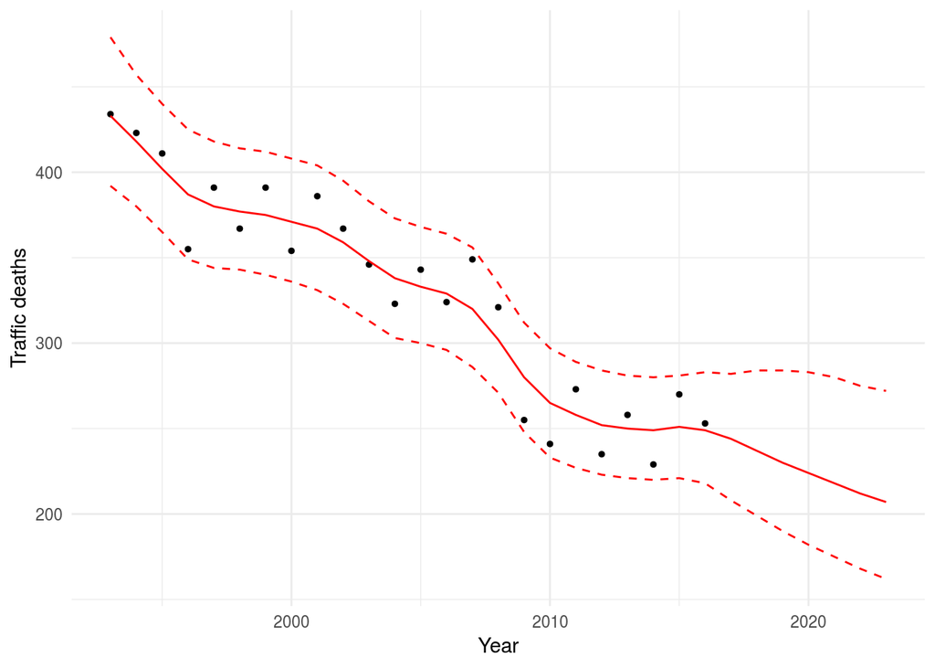

```r
gp_params <- extract(fit_gp)
mu <- apply(t(gp_params$y_predict), 1, quantile, c(0.05, 0.5, 0.95)) %>%
  t() %>% data.frame(x = x_predict, .) %>% gather(pct, y, -x)
pfit <- ggplot() +
   geom_point(aes(year, deaths), data = deaths, size = 1) +
  geom_line(aes(x, y, linetype = pct), data = mu, color = 'red') +
  scale_linetype_manual(values = c(2,1,2)) +
  labs(x = 'Year', y = 'Traffic deaths') +
  guides(linetype = F)
(pfit)
```

Finally we compare models using PSIS-LOO predictive performance estimates.

```r
(loo_lin<-loo(fit_lin))
```

```
Computed from 2000 by 24 log-likelihood matrix

         Estimate   SE
elpd_loo   -115.2  5.4
p_loo         3.3  0.8
looic       230.5 10.8
------
Monte Carlo SE of elpd_loo is 0.1.

All Pareto k estimates are good (k < 0.5).
See help('pareto-k-diagnostic') for details.
```

```r
(loo_gam<-loo(fit_gam))
```

```
Computed from 4000 by 24 log-likelihood matrix

         Estimate  SE
elpd_loo   -111.7 3.3
p_loo         7.2 1.3
looic       223.4 6.6
------
Monte Carlo SE of elpd_loo is 0.1.

Pareto k diagnostic values:
                         Count Pct.    Min. n_eff
(-Inf, 0.5]   (good)     22    91.7%   539
 (0.5, 0.7]   (ok)        2     8.3%   1074
   (0.7, 1]   (bad)       0     0.0%   <NA>
   (1, Inf)   (very bad)  0     0.0%   <NA>

All Pareto k estimates are ok (k < 0.7).
See help('pareto-k-diagnostic') for details.
```

```r
compare(loo_lin, loo_gam)
```

```
elpd_diff        se
      3.5       2.9
```

```r
log_lik_gp <- extract_log_lik(fit_gp, merge_chains = FALSE)
(loo_gp<-loo(log_lik_gp, r_eff = relative_eff(exp(log_lik_gp))))
```

```
Computed from 8000 by 24 log-likelihood matrix

         Estimate  SE
elpd_loo   -111.7 2.8
p_loo         8.8 1.4
looic       223.3 5.5
------
Monte Carlo SE of elpd_loo is 0.1.

Pareto k diagnostic values:
                         Count Pct.    Min. n_eff
(-Inf, 0.5]   (good)     13    54.2%   565
 (0.5, 0.7]   (ok)       11    45.8%   656
   (0.7, 1]   (bad)       0     0.0%   <NA>
   (1, Inf)   (very bad)  0     0.0%   <NA>

All Pareto k estimates are ok (k < 0.7).
See help('pareto-k-diagnostic') for details.
```

```r
compare(loo_lin, loo_gp)
```

```
elpd_diff        se
      3.6       3.2
```

There are no practical differences in predictive performance, which is partially due to small number of observations. Based on the posterior predictive distributions there are clear differences in the future predictions.

# Licenses

- Code © 2017-2018, Aki Vehtari, licensed under BSD-3.
- Text © 2017-2018, Aki Vehtari, licensed under CC-BY-NC 4.0.